# Gene Expression Analysis Using R

Case Study: Interferon Regulatory Factor 6 (*IRF6*)

Macrh 17, 2018

# 1 Objectives

- Load microarray dataset into R
- Explore the dataset with basic visualizations
- Identify differentially expressed genes (DEGs)
- Generate annotation of the DEGs

[figure not shown]

# 2 Cleft Lip and Palate 1/3

Cleft lip and cleft palate (**CLP**) are splits in the upper lip, the roof of the mouth (palate) or both. They result when facial structures that are developing in an unborn baby do not close completely. CLP is one of the most common birth defects with a frequency of 1/700 live births.

[figure not shown]

Cleft lip and palate

# 3 Cleft Lip and Palate 2/3

Children with cleft lip with or without cleft palate face a variety of challenges, depending on the type and severity of the cleft.

- **Difficulty feeding.** One of the most immediate concerns after birth is feeding.
- **Ear infections and hearing loss.** Babies with cleft palate are especially at risk of developing middle ear fluid and hearing loss.
- **Dental problems.** If the cleft extends through the upper gum, tooth development may be affected.
- **Speech difficulties.** Because the palate is used in forming sounds, the development of normal speech can be affected by a cleft palate. Speech may sound too nasal.

*Reference*: [Mayo Foundation for Medical Education and Research](https://www.mayoclinic.org/diseases-conditions/cleft-palate/symptoms-causes/syc-20370985)

# 4 Cleft Lip and Palate 3/3

- DNA variation in Interferon Regulatory Factor 6 (**IRF6**) causes Van der Woude syndrome (**VWS**)
- VWS is the most common syndromic form of cleft lip and palate.
- However, the causing variant in IRF6 has been found in *only* 70% of VWS families!
- IRF6 is a **transcription factor** with a conserved helix-loop-helix DNA binding domain and a less well-conserved protein binding domain.

*Reference*: [Hum Mol Genet. 2014 May 15; 23(10): 2711–2720](http://doi.org/10.1093/hmg/ddt664)

# 5 Question

Given:

1. The pathogenic variant in IRF6 exists in only 70% of the VWS families
2. IRF6 is a transcription factor

How can we identify other genes that might be involved in the remaining 30% of the VWS families?

# 6 Hint

- Usually, genes that are regulated by a transcription factor belong to the same biological process or pathway.
- Therefore, by comparing the gene expression patterns between wild-type (functional) *Irf6* and knockout (non-functional) *Irf6*, it could be possible to identify genes that are regulated (targeted) by *Irf6*.

# 7 Hypothesis

- $H_O : \mu_{WT} = \mu_{KO}$
- $H_A : \mu_{WT} \ne \mu_{KO}$
- Where $\mu$ is the *mean* of the gene expression values of a gene.
- **One**-sided or **Two**-sided testing?

# 8 Why Microarray?

[figure not shown]

# 9 Original Paper

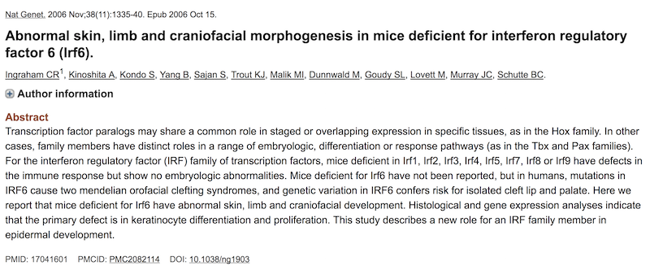

PMID: 17041601

# 10 Experimental Design

- 3 IRF6 wild-type (+/+) and 3 knockout (-/-) mouse embryos.
- E17.5 embryos were removed from euthanized mothers.
- Skin was removed from embryos.
- Total RNA was isolated from the skin.
- Resultant RNA was hybridized to Affymetrix GeneChip Mouse Genome 430 2.0 arrays.

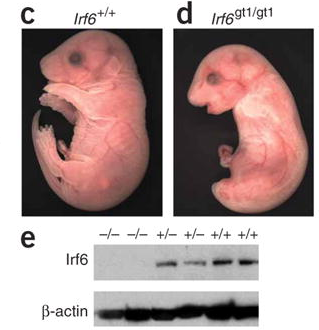

# 11 Dataset

- The original dataset can be obtained from NCBI GEO with accession GSE5800
- `Irf6.xlsx` (Excel): https://goo.gl/hrmnct
- `Irf6.tsv` (Tab-separated values): https://goo.gl/tYAz6v

# 12 Loading

We are going to load the dataset from the `.tsv` file (`Irf6.tsv`) into a variable called `data` using the [`read.table`](http://www.inside-r.org/r-doc/utils/read.table) function.  
`data` here is just an arbitrary **varilable** name to hold the result of `read.table` and it can be called/named *almost* anything.  
See [The State of Naming Conventions in R](http://journal.r-project.org/archive/2012-2/RJournal_2012-2_Baaaath.pdf) for more information on naming **varilables** in `R`.

```r
# Load the data from a file into a varilable
data = read.table("https://goo.gl/tYAz6v", header = TRUE, row.names = 1)

# Convert the data.frame (table) in a matrix (numeric)
data = as.matrix(data)
```

**Note:** the hash sign (`#`) indicates that what comes after is a *comment*. Comments are for documentation and readability of the `R` code and they are not evaluated (or executed).

# 13 Checking

```r
dim(data) # Dimension of the dataset
head(data) # First few rows
```

[output not shown]

# 14 Number of Genes and IDs

```r
number_of_genes = nrow(data)
number_of_genes

ids = row.names(data)
head(ids)
length(ids)
```

[output not shown]

# 15 Exploring

Check the behavior of the data (e.g., normal?, skewed?)

```r
hist(data, col = "gray", main="Histogram")
```

[output not shown]

# 16 Transforming

$log_2$ transformation (why?)

```r
data2 = log2(data)
hist(data2, col = "gray", main="Histogram")
```

[output not shown]

# 17 Boxplot

```r
colors = c(rep("navy", 3), rep("orange", 3))
boxplot(data2, col = colors, las = 2)
```

[output not shown]

# 18 Clustering 1/2

Hierarchical clustering of the **samples** (i.e., columns) based on the [correlation coefficients](http://en.wikipedia.org/wiki/Pearson_product-moment_correlation_coefficient) of the expression values

```r
hc = hclust(as.dist(1 - cor(data2)))
plot(hc)
```

[output not shown]

# 19 Clustering 2/2

# 20 Splitting Data Matrix into Two 1/2

```r
ko = data2[, 1:3] # KO matrix
head(ko)
```

[output not shown]

# 21 Splitting Data Matrix into Two 2/2

```r
wt = data2[, 4:6] # WT matrix
head(wt)
```

[output not shown]

# 22 Gene (Row) Mean Expression

```r
# Compute the means of the KO samples
ko.means = rowMeans(ko)
head(ko.means)

# Compute the means of the WT samples
wt.means = rowMeans(wt)
head(wt.means)
```

[output not shown]

# 23 Scatter 1/2

```r
plot(ko.means ~ wt.means)
abline(0, 1, col = "red") # Diagonal line
```

[output not shown]

# 24 Scatter 2/2

```r
pairs(data2) # All pairwise comparisons
```

[output not shown]

# 25 Differentially Expressed Genes (DEGs)

To identify DEGs, we will identify:

- **Biologically** significantly differentially expressed
- **Statistically** significantly differentially expressed

Then, we will take the **overlap** (**intersection**) of the two sets